# M09-2-Application-Data-Import-Export

Author

Dia Kaewdee

# Preparation

In this assignment, I practiced importing, cleaning, exporting, joining, and visualizing data from several different sources. I also organized my project using the folder structure provided in the GitHub repository and confirmed my results after each major data manipulation step.

```r
# Load the packages needed for this assignment

library(tidyverse)
library(readxl)
library(openxlsx)
library(lubridate)
library(janitor)
library(naniar)
library(rvest)
library(stringr)
library(WDI)
library(countrycode)
library(haven)
library(labelled)
library(sjlabelled)
library(ggrepel)
library(scales)
```

# Question 1: Dealing with csv file

## Q1.1

The original CSV file uses semicolons instead of commas, so I imported it using the appropriate process. After importing the data, I examined the variable types and converted the `order_date` variable into a Date format so the data would be ready for analysis.

```r
item_csv <- read_delim(
  "data/items_ordered.csv",
  delim = ";",
  show_col_types = FALSE
)

glimpse(item_csv)
```

```
Rows: 32
Columns: 5
$ customerid <dbl> 10330, 10101, 10298, 10101, 10299, 10339, 10449, 10439, 101…
$ order_date <chr> "30/jun/99", "30/jun/99", "01/jul/99", "01/jul/99", "06/jul…
$ item       <chr> "Pogo stick", "Raft", "Skateboard", "Life Vest", "Parachute…
$ quantity   <dbl> 1, 1, 1, 4, 1, 1, 1, 2, 1, 1, 1, 2, 1, 1, 1, 1, 1, 1, 3, 4,…
$ price      <dbl> 28.00, 58.00, 33.00, 125.00, 1250.00, 4.50, 180.79, 25.50, …
```

```r
item_csv <- item_csv |>
  mutate(
    order_date = dmy(order_date)
  )

item_csv
```

```
# A tibble: 32 × 5
   customerid order_date item       quantity  price
        <dbl> <date>     <chr>         <dbl>  <dbl>
 1      10330 1999-06-30 Pogo stick        1   28
 2      10101 1999-06-30 Raft              1   58
 3      10298 1999-07-01 Skateboard        1   33
 4      10101 1999-07-01 Life Vest         4  125
 5      10299 1999-07-06 Parachute         1 1250
 6      10339 1999-07-27 Umbrella          1    4.5
 7      10449 1999-08-13 Unicycle          1  181.
 8      10439 1999-08-14 Ski Poles         2   25.5
 9      10101 1999-08-18 Rain Coat         1   18.3
10      10449 1999-09-01 Snow Shoes        1   45
# ℹ 22 more rows
```

## Q1.2

Next, I found the most expensive item in the dataset by identifying the maximum price and filtering the corresponding row.

```r
# Find the most expensive item

most_expensive_item <- item_csv |>
  filter(price == max(price, na.rm = TRUE)) |>
  select(item, price)

most_expensive_item
```

```
# A tibble: 1 × 2
  item      price
  <chr>     <dbl>
1 Parachute  1250
```

# Question 2: Dealing with excel file

## Q2.1

For this question, I imported the Excel version of the items ordered dataset and named it `item_excel`. I also examined the structure and printed the data to confirm that the Excel file imported correctly.

```r
# Import the Excel file

item_excel <- read_excel("data/items_ordered.xlsx")

# Examine the structure of the Excel data
glimpse(item_excel)
```

```
Rows: 32
Columns: 5
$ customerid <dbl> 10330, 10101, 10298, 10101, 10299, 10339, 10449, 10439, 101…
$ order_date <chr> "36341", "36341", "36342", "36342", "36347", "36368", "13/A…
$ item       <chr> "Pogo stick", "Raft", "Skateboard", "Life Vest", "Parachute…
$ quantity   <dbl> 1, 1, 1, 4, 1, 1, 1, 2, 1, 1, 1, 2, 1, 1, 1, 1, 1, 1, 3, 4,…
$ price      <chr> "28.00", "58.00", "33.00", "125.00", "1250.00", "4.50", "18…
```

```r
# Print the imported data
item_excel
```

```
# A tibble: 32 × 5
   customerid order_date  item       quantity price
        <dbl> <chr>       <chr>         <dbl> <chr>
 1      10330 36341       Pogo stick        1 28.00
 2      10101 36341       Raft              1 58.00
 3      10298 36342       Skateboard        1 33.00
 4      10101 36342       Life Vest         4 125.00
 5      10299 36347       Parachute         1 1250.00
 6      10339 36368       Umbrella          1 4.50
 7      10449 13/Aug/1999 Unicycle          1 180.79
 8      10439 14/Aug/1999 Ski Poles         2 25.50
 9      10101 18/Aug/1999 Rain Coat         1 18.30
10      10449 01/Sep/1999 Snow Shoes        1 45.00
# ℹ 22 more rows
```

## Q2.2

Next, I created a chart showing the count of item quantities ordered. I also created an `images` folder and saved the same chart as PNG, PDF, and JPEG files.

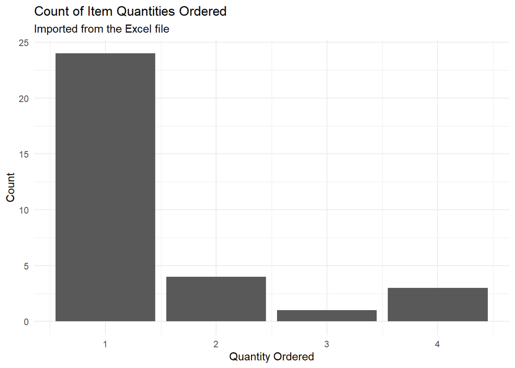

```r
# Create an images folder if it does not already exist

dir.create("images", showWarnings = FALSE)

# Create a chart showing the count of quantity ordered

quantity_chart <- item_excel |>
  ggplot(aes(x = quantity)) +
  geom_bar() +
  labs(
    title = "Count of Item Quantities Ordered",
    subtitle = "Imported from the Excel file",
    x = "Quantity Ordered",
    y = "Count"
  ) +
  theme_minimal()

# Print the chart
quantity_chart
```

```r
# Save the chart in different file formats

ggsave("images/quantity_chart.png", quantity_chart, width = 7, height = 5)

ggsave("images/quantity_chart.pdf", quantity_chart, width = 7, height = 5)

ggsave("images/quantity_chart.jpeg", quantity_chart, width = 7, height = 5)
```

# Question 3: Importing from the clipboard and cleaning NA’s or “–”

## Q3.1

```r
# Import the Key Executives table from the clipboard

dis_exec <- read.delim(
  "clipboard",
  sep = "\t",
  header = TRUE,
  stringsAsFactors = FALSE
)

# Print the imported data
dis_exec
```

[output not shown]

[output cut: 20 more lines]

```r
# Clean the column names
dis_exec_clean <- dis_exec |>
  clean_names()

# Replace "N/A" and "--" with proper missing values
dis_exec_clean <- dis_exec_clean |>
  mutate(
    across(
      where(is.character),
      ~na_if(.x, "N/A")
    )
  ) |>
  mutate(
    across(
      where(is.character),
      ~na_if(.x, "--")
    )
  )

# Print the cleaned data
dis_exec_clean
```

[output not shown]

[output cut: 20 more lines]

## Q3.2

Next, I exported the cleaned Disney executive data as both a CSV file and an Excel file into the project’s `data` folder.

```r
# Save the cleaned data as a CSV file

write_csv(
  dis_exec_clean,
  "data/dis_exec_clean.csv"
)

# Save the cleaned data as an Excel file

write.xlsx(
  dis_exec_clean,
  "data/dis_exec_clean.xlsx"
)

# Print the cleaned data
dis_exec_clean
```

[output not shown]

[output cut: 20 more lines]

# Question 4: Web scraping

## Q4.1

For this question, I used web scraping to read the archived IMDb Top 250 movies page. I first saved the URL and then scraped the movie titles into a vector called `top_movies`.

```r
# IMDb Top 250 URL

url <- "https://web.archive.org/web/20220201012049/https://www.imdb.com/chart/top/"

# Scrape the movie titles

top_movies <- url |>
  read_html() |>
  html_elements(".titleColumn a") |>
  html_text(trim = TRUE)

# Check the number of movies scraped
length(top_movies)
```

```
[1] 250
```

```r
# Print the movie titles
top_movies
```

```
  [1] "The Shawshank Redemption"
  [2] "The Godfather"
  [3] "The Godfather: Part II"
  [4] "The Dark Knight"
  [5] "12 Angry Men"
  [6] "Schindler's List"
  [7] "The Lord of the Rings: The Return of the King"
  [8] "Pulp Fiction"
  [9] "The Good, the Bad and the Ugly"
 [10] "The Lord of the Rings: The Fellowship of the Ring"
 [11] "Fight Club"
 [12] "Forrest Gump"
 [13] "Inception"
 [14] "The Lord of the Rings: The Two Towers"
 [15] "Star Wars: Episode V - The Empire Strikes Back"
```

[output cut: 235 more lines]

## Q4.2

Next, I scraped the movie years from the same IMDb page. I cleaned the year values by removing the parentheses and converting the result into a numeric variable.

```r
# Scrape the movie release years

year <- url |>
  read_html() |>
  html_elements(".secondaryInfo") |>
  html_text(trim = TRUE) |>
  str_remove_all("\\(") |>
  str_remove_all("\\)") |>
  as.numeric()

# Check the number of years scraped
length(year)
```

```
[1] 250
```

```r
# Print the years
year
```

```
  [1] 1994 1972 1974 2008 1957 1993 2003 1994 1966 2001 1999 1994 2010 2002 1980
 [16] 1999 1990 1975 1954 1995 1991 2002 1946 1997 2021 1998 1977 2014 2001 1999
 [31] 2019 1994 1962 2002 1991 1985 1995 1960 1994 1936 1988 1998 2014 2000 1931
 [46] 2006 2011 2006 1942 1968 1954 1988 1979 1979 2000 1981 1940 2012 2006 1957
 [61] 1950 2008 2018 1957 2018 1980 1964 1997 2003 2019 2016 2017 2012 1986 1984
 [76] 2019 2018 1981 1963 2009 1995 1984 1999 1995 2009 1997 2020 1983 1985 1968
 [91] 1992 2007 1958 1931 2012 1941 2000 1952 1959 2004 1952 1948 1962 1921 1987
[106] 2010 1960 2016 1944 1927 2011 2020 1976 1971 1973 1983 2000 2019 2001 1962
[121] 2010 1965 2009 1955 1989 1995 1997 1985 1961 1988 2018 1950 2004 1950 1975
[136] 1959 2005 1992 1997 2021 2004 2013 1961 2007 1995 1963 1948 2006 2001 2009
[151] 1980 1974 1988 2010 1998 2007 2019 1954 1982 1925 2017 1957 1980 1975 1999
[166] 1998 1993 1957 1949 2003 2005 1982 1996 1996 1957 2015 2003 2003 2011 1939
[181] 1953 1954 2005 2014 2013 1979 2014 1978 1926 1966 2008 1924 1995 2009 2002
[196] 1939 1975 1993 2021 2016 1969 2014 2015 1928 2018 2019 2013 1942 1998 1989
[211] 2011 1959 2010 2015 1978 2004 1953 1986 2016 1976 2017 2016 1995 2009 1967
[226] 2012 1959 1986 2015 2001 1940 1979 2000 2004 1996 2013 1976 2000 2007 1984
[241] 2020 2004 1934 1982 2013 1966 1957 2019 1966 1987
```

## Q4.3

Finally, I scraped the IMDb ratings from the same page and converted them into numeric values so they can be used for sorting and analysis later.

```r
# Scrape the IMDb ratings

rating <- url |>
  read_html() |>
  html_elements("td.ratingColumn.imdbRating strong") |>
  html_text(trim = TRUE) |>
  as.numeric()

# Check the number of ratings scraped
length(rating)
```

```
[1] 250
```

```r
# Print the ratings
rating
```

```
  [1] 9.2 9.1 9.0 9.0 8.9 8.9 8.9 8.8 8.8 8.8 8.7 8.7 8.7 8.7 8.7 8.7 8.6 8.6
 [19] 8.6 8.6 8.6 8.6 8.6 8.6 8.6 8.6 8.5 8.5 8.5 8.5 8.5 8.5 8.5 8.5 8.5 8.5
 [37] 8.5 8.5 8.5 8.5 8.5 8.5 8.5 8.5 8.5 8.5 8.5 8.5 8.4 8.4 8.4 8.4 8.4 8.4
 [55] 8.4 8.4 8.4 8.4 8.4 8.4 8.4 8.4 8.4 8.4 8.4 8.4 8.4 8.3 8.3 8.3 8.3 8.3
 [73] 8.3 8.3 8.3 8.3 8.3 8.3 8.3 8.3 8.3 8.3 8.3 8.3 8.3 8.3 8.3 8.3 8.3 8.3
 [91] 8.3 8.3 8.3 8.3 8.3 8.3 8.3 8.3 8.3 8.3 8.3 8.3 8.3 8.2 8.2 8.2 8.2 8.2
[109] 8.2 8.2 8.2 8.2 8.2 8.2 8.2 8.2 8.2 8.2 8.2 8.2 8.2 8.2 8.2 8.2 8.2 8.2
[127] 8.2 8.2 8.2 8.2 8.2 8.2 8.2 8.2 8.2 8.2 8.2 8.2 8.2 8.2 8.2 8.2 8.2 8.2
[145] 8.2 8.2 8.2 8.1 8.1 8.1 8.1 8.1 8.1 8.1 8.1 8.1 8.1 8.1 8.1 8.1 8.1 8.1
[163] 8.1 8.1 8.1 8.1 8.1 8.1 8.1 8.1 8.1 8.1 8.1 8.1 8.1 8.1 8.1 8.1 8.1 8.1
[181] 8.1 8.1 8.1 8.1 8.1 8.1 8.1 8.1 8.1 8.1 8.1 8.1 8.1 8.1 8.1 8.1 8.1 8.1
[199] 8.1 8.1 8.1 8.1 8.1 8.1 8.1 8.1 8.1 8.1 8.1 8.1 8.1 8.1 8.1 8.1 8.1 8.1
[217] 8.1 8.1 8.1 8.1 8.1 8.1 8.1 8.0 8.0 8.0 8.0 8.0 8.0 8.0 8.0 8.0 8.0 8.0
[235] 8.0 8.0 8.0 8.0 8.0 8.0 8.0 8.0 8.0 8.0 8.0 8.0 8.0 8.0 8.0 8.0
```